# Multivariate Analysis | Part 2

## Clustering, PCA and Analysis on Customer Table

# **Author:** Chimdia Kabuo, Pauline Korukundo, Anushka Bhat

# **Supervisor:** Alessandro Selvitella

### Install Packages

Run Once!

```r
# Save current warning behavior
old_warning <- getOption("warn")

# Temporarily suppress warnings
options(warn = -1)

# Define a list of packages to install
packages_to_install <- c("reshape2", "car", "FactoMineR", "GGally", "dbscan", "factoextra", "gridExtra")

# Install and load each package if not already installed
for (package in packages_to_install) {
  if (!requireNamespace(package, quietly = TRUE)) {
    install.packages(package)
  }
}

cat("Done")

# Restore original warning behavior
options(warn = old_warning)
```

```
Done
```

### Load Packages

```r
library(lubridate)
library(tidyverse)
library(ggplot2)
library(reshape2)
library(GGally)
library(dplyr)
library(cluster)
library(stats)
library(dbscan)
library(car)
library(FactoMineR)
library(factoextra)
library(gridExtra)

cat("Done")
```

```
Done
```

```r
# Set global display option to avoid scientific notation
options(scipen = 999)
```

## Setting Up The Dataset

Creating Functions - Clean Data and Get Eligible Population

Intersect the dataset with the eligible population

### Function | Clean Data

```r
## remove leading/trailing white space, convert blank cells to NA, convert POSIX object to Date, and convert from character to numeric where appropriate
Clean_Data_fx <- function(df1){
  ## Convert blanks to NA. Need to do this outside of dtplyr to recover type
  df1 <- map_df(df1, function(x){
    # Everything will be convert to character type. Capture the type to later convert back
    Type_use <- switch(match(typeof(x), c("logical", "integer", "double", "character")),
                       as.logical,
                       as.integer,
                       as.double,
                       as.character)

    Convert <- map_lgl(class(x), function(y){
      y %in% c("POSIXct", "POSIXt", "Date")
    })

    if(any(Convert)){
      return(as.Date(x))

    }else if(typeof(x) == "character"){
      return(tryCatch(type.convert(Type_use(gsub("^$", NA, trimws(x))), as.is = TRUE), error = function(e) x))

    }else{
      return(tryCatch(type.convert(Type_use(gsub("^$", NA, x)), as.is = TRUE), error = function(e) x))
    }

  })

  df1 <- df1 %>% mutate(across(where(is.factor), ~ as.character(.x)))

  return(df1)

}
```

### Function | Get Eligible Population

```r
## 3 months from end of August. Used to determine eligible members and checking and savings accounts
Startdate <- as.Date("2023-06-01", origin = "1970-01-01")


## Start with customer data to determine elgibility then look at account data
df_Cust <- readRDS('/home/x-ckabuo/corporate/3rivers-membership/projects/x-ckabuo/data/Customer_Table.rds')

## active member from at least June 1st 2023 and is currently active the customer type is "Personal" and the member is at least 18 years old
ID_use <- df_Cust %>%
  Clean_Data_fx(.) %>%          ## this is a self-written function to clean the data
  filter(datejoined < Startdate,
         isactive == "Yes",
         type == "Personal",
         age >= 18) %>%
  pull(id)

## read in customer to account table
df_CtA <- readRDS('/home/x-ckabuo/corporate/3rivers-membership/projects/x-ckabuo/data/CustomerToAccount_Table.rds')

## member needs to have an active checking or savings account that was opened before June 1st.
# Doesn't matter if they are the primary on the account. Use the customer to account table because the account table will only have primary member
df_Population <- df_CtA %>%
  filter(application %in% c("CH", "SV")) %>%
  Clean_Data_fx(.) %>%                          ## this is a self-written function to clean the data
  filter(customerid %in% ID_use,
         startdatetime < Startdate,
         isactive == "Yes") %>%
  mutate(accountid = as.character(accountid)) ## make account id a string instead of a number


## read in account table. Need the  product market field
df_Acct <- readRDS('/home/x-ckabuo/corporate/3rivers-membership/projects/x-ckabuo/data/Account_Table.rds')

## last step is to check whether any of the checking or saving accounts are "Consumer". If not then drop
df_Population  <- df_Acct %>%
  select(number, productmarket, productname) %>%
  left_join(df_Population, ., by = c("accountid" = "number")) %>%
  filter(is.na(productmarket == "Consumer") | productmarket == "Consumer",  ## some productmarket labels are missing which would count as "Consumer"
         productname != "Business Money Market") %>%                        #  except "Business Money Market"
  distinct(customerid)   ## only want unique customer id.

  ## Need Secondary_ID to identify other memberships of the member. We will want to use that data for the member
df_Population <- df_Cust %>%
  select(customerid = id, Secondary_ID) %>%
  filter(customerid %in% df_Population$customerid) %>%
  mutate(Secondary_ID = ifelse(is.na(Secondary_ID), customerid, Secondary_ID)) ## assigned customerid when secondary is missing to filter when merging

#saveRDS(df_Population, file.path(myPaths$output, "Eligible_Members.rds"))
write.csv(df_Population, file ='/home/x-ckabuo/corporate/3rivers-membership/projects/x-ckabuo/prime/Eligible_Members2.csv')

cat("Done")
```

```
Done
```

```r
# Segment the data based on geographical location
segmented_data <- df_Cust %>%
  Clean_Data_fx(.) %>%
  filter(datejoined < Startdate,
         isactive == "Yes",
         type == "Personal",
         age >= 18) %>%
  select(id, datejoined) %>%
  group_by(datejoined) %>%
  summarize(num_members = n())

# Print the segmented data
print(segmented_data)
```

```
# A tibble: 12,484 x 2
   datejoined num_members
   <date>           <int>
 1 1194-10-20           1
 2 1935-08-26           1
 3 1947-04-22           2
 4 1953-09-30           1
 5 1956-09-29           1
 6 1960-01-01           1
 7 1972-01-01           1
 8 1972-07-07           1
 9 1973-09-28           1
10 1974-03-19           2
# i 12,474 more rows
```

### Intersect Selected Data Variables

Intersect selected data variables from eligible population

```r
I5=intersect(df_Cust['id'][,1], df_Population['customerid'][,1])
```

Check length of the intersect

```r
length(I5)
```

127217

### Check Number of Unique Rows

```r
row_index5 <- c()
for (j in 1:length(I5)) {
row_index5 <- c(row_index5,which(df_Cust['id'] == I5[j]))
}
row_index5 <- unique(row_index5)
head(row_index5)
```

1. 166

2. 169

3. 171

4. 172

5. 173

6. 174

#### Define dataframe to hold the eligible data

```r
# data frame to hold the selected variables based on the indices specified in `row_index5`
df_Cust_5 <- df_Cust[row_index5,]
```

## Descriptive Analysis

### Extract Numeric Columns from the Selected Data variables

```r
##**** Identify numeric columns ****##
numCols <- unlist(lapply(df_Cust_5, is.numeric))

##**** Print Subset of Numeric Columns ****##
CustNum <- df_Cust_5[, numCols]
```

#### Replacing NAs & Blank values with 0

This is done because there are an overwhelming number of NAs in the dataset which could cause issues with analysis and visualization

```r
# Replace NA values with 0
CustNum[is.na(CustNum)] <- 0
```

Replacing blank values with 0

```r
# Replace blank values
CustNum[CustNum == ""] <- 0
```

#### Checking for Unique Values

Since some of our columns appear to have fewer unique values, we will test to see if this is true

```r
# Check for unique values in all columns of our data
unique_values <- sapply(CustNum, function(x) length(unique(x)))
unique_values
```

**age**

89

**ageatjoining**

105

**autoloansprincipalbalance**

17995

**cdaccountbalance**

3951

**checkingaccountbalance**

61660

**closestbranchdistance**

7042

**dayssincejoining**

12454

**demandaccountbalance**

79404

**iraaccountbalance**

432

**mortgagesprincipalbalance**

11507

**numberofcreditcards**

10

**numberofdebitcards**

20

**numberofaccounts**

40

**numberofautoloans**

16

**numberofcdaccounts**

24

**numberofcheckingaccounts**

21

**numberofhomeequityloans**

3

**numberofloans**

20

**numberofmortgages**

9

**numberofsavingsaccounts**

22

**totalloansprincipalbalance**

34444

**transactionamount_last30**

71294

**transactioncount_last30**

362

**HH_Number**

69983

### Generate a set of boxplots for each variable in the `Custnum` data frame

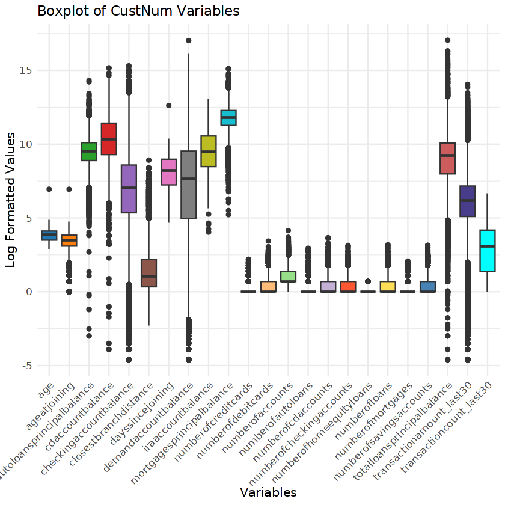

```r
# Save current warning behavior
old_warning <- getOption("warn")

# Temporarily suppress warnings
options(warn = -1)

# Melt the data into long format, using 'HH_Number' as the id variable
melted_data <- reshape2::melt(CustNum, id.vars = "HH_Number")

# Create a custom color palette
my_colors <- c("#1f77b4", "#ff7f0e", "#2ca02c", "#d62728", "#9467bd",
               "#8c564b", "#e377c2", "#7f7f7f", "#bcbd22", "#17becf",
               "#aec7e8", "#ffbb78", "#98df8a", "#ff9896", "#c5b0d5",
               "#ff5733", "#6a1b9a", "#ffdd57", "#2e8b57", "#4682b4",
               "#cd5c5c", "#483d8b", "#00ffff", "#dda0dd")

# Create a boxplot for each column with custom colors
ggplot(melted_data, aes(x = variable, y = log(value), fill = variable)) +
  geom_boxplot() +
  scale_fill_manual(values = my_colors) +
  theme_minimal() +
  theme(axis.text.x = element_text(angle = 45, hjust = 1),
        legend.position = "none",
        panel.spacing = unit(5.0, "lines"),
        strip.text = element_text(face = "bold"),
        axis.text = element_text(size = 10),
        axis.title = element_text(size = 12)) +
  labs(title = "Boxplot of CustNum Variables",
       x = "Variables",
       y = "Log Formatted Values")

# Restore original warning behavior
options(warn = old_warning)
```

### Dropping Irrelevant Variables

John recommends dropping the `hasestatement` variable

Other recommended variables to drop are those that include any "balance" or "transactionamount"

#### List Variables to Drop

```r
# keywords is a vector of keywords we want to drop
keywords <- c("balance", "transaction")

# Find indices of the columns containing the keywords
Vars2Drop <- grep(paste(keywords, collapse = "|"), names(CustNum))

# Drop the columns containing the keywords
CustNum_drop <- CustNum[, -Vars2Drop]

cat("Done")
```

```
Done
```

##### Summary

After dropping the columns as recommended by John | Using the keywords, we find that 9 columns have been dropped.

We will perform "Clustering", "PCA", and other Analysis on the remaining variables!

However, we can still work with those variables at a later date should we so choose!!

```r
names(CustNum_drop)
```

1. 'age'

2. 'ageatjoining'

3. 'closestbranchdistance'

4. 'dayssincejoining'

5. 'numberofcreditcards'

6. 'numberofdebitcards'

7. 'numberofaccounts'

8. 'numberofautoloans'

9. 'numberofcdaccounts'

10. 'numberofcheckingaccounts'

11. 'numberofhomeequityloans'

12. 'numberofloans'

13. 'numberofmortgages'

14. 'numberofsavingsaccounts'

15. 'HH_Number'

## Clustering Analysis

### Compute K-means Clustering

Using Elbow Method and within-cluster sum of squares (WCSS) on the `CustNum_drop` data frame

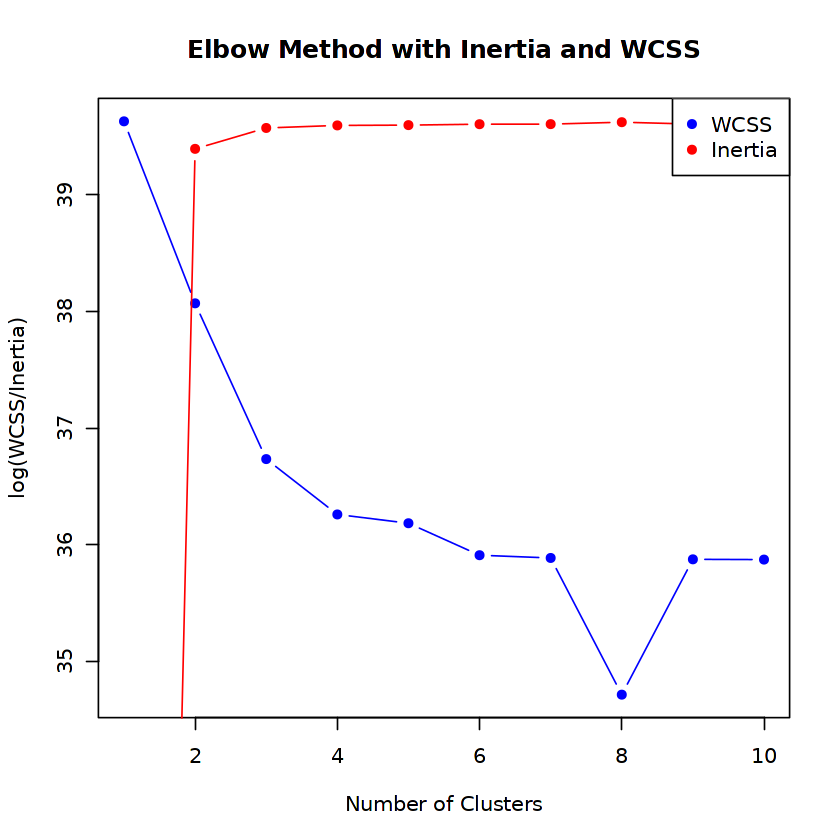

```r
# Create vectors to store the within-cluster sum of squares (WCSS) for different values of k
wcss <- numeric(10)
# Create vectors to store inertia for different values of k
inertia <- numeric(10)

# Define a range of values for k
k_range <- 1:10

# Iterate over each value of k
for (k in k_range) {
  # Compute K-means clustering for dataframe with variables dropped
  kmeans_model <- kmeans(CustNum_drop, centers = k)

  # Store the within-cluster sum of squares (WCSS)
  wcss[k] <- kmeans_model$tot.withinss

  # Store the inertia
  inertia[k] <- kmeans_model$totss - kmeans_model$tot.withinss
}

# Plot the within-cluster sum of squares (WCSS) and inertia against number of clusters
plot(k_range, log(wcss), type = "b", col = "blue", pch = 16,
     xlab = "Number of Clusters", ylab = "log(WCSS/Inertia)",
     main = "Elbow Method with Inertia and WCSS")

# Add inertia to the plot
points(k_range, log(inertia), type = "b", col = "red", pch = 16)

# Add legend
legend("topright", legend = c("WCSS", "Inertia"), col = c("blue", "red"), pch = 16)
```

#### Summary

Using the plot within-cluster sum of squares (WCSS), we look for the `elbow point`, where the rate of decrease in WCSS slows down and might be indicative of a suitable number of clusters.

Using the plot of the inertia helps us to estimate the point where linear decrease starts in the visualization.

In the case of this visualization, the point is **4**

#### John suggests that we convert both `age` and `ageatjoining` into years

We will use `dayssincejoining` converted into `yearsofmember`

```r
# Converting `dayssincejoining` to `yearsofmember`
CustNum_drop <- CustNum_drop %>% mutate(yearsofmember = dayssincejoining / 365)
```

Notice that `ageatjoining` is dropped in the subset  
It can be used for other analysis that are not k-means clustering  
*`df_KMeans1` has one variable extra*

### Creating several subsets of the data for performing K-means clustering

```r
# Create deep copies of the original numerical dataframe `CustNum`
df_KMeans1 <- CustNum_drop[, c("age", "numberofmortgages", "closestbranchdistance", "yearsofmember", "numberofsavingsaccounts")]

df_KMeans2 <- CustNum_drop[, c("yearsofmember", "numberofcreditcards", "numberofdebitcards", "numberofaccounts")]

df_KMeans3 <- CustNum_drop[, c("numberofaccounts", "numberofautoloans", "numberofcdaccounts", "numberofcheckingaccounts")]

df_KMeans4 <- CustNum_drop[, c("numberofcheckingaccounts", "numberofhomeequityloans", "numberofloans", "numberofmortgages")]

cat("Done")
```

```
Done
```

#### Summary

The data we are working with is large and therefore puts a strain on computation

Subsetting the data helps in

Dimensionality Reduction - which reduces the number of variables to a more manageable size.

Computational Efficiency - because performing kmeans can be computationally expensive as the number of variables increases.

#### Performing K-means Clustering on the subsets of the dataframe

```r
# Define a function to perform K-means clustering on multiple data frames
perform_kmeans <- function(df_list, k) {
  results <- list()  # Create an empty list to store results

  # Iterate over each data frame in the list
  for (i in seq_along(df_list)) {
    # Perform K-means clustering on the current data frame
    kmeans_result <- kmeans(df_list[[i]], centers = k)

    # Store cluster assignments and cluster centers in the results list
    results[[i]] <- list(cluster_assignments = kmeans_result$cluster,
                         cluster_centers = kmeans_result$centers)
  }

  # Return the list of results
  return(results)
}

# Apply K-means clustering to each dataframe
k <- 4 # Number of clusters

# List of data frames
df_list <- list(df_KMeans1, df_KMeans2, df_KMeans3, df_KMeans4)

# Perform K-means clustering on each data frame
kmeans_results <- perform_kmeans(df_list, k)

# Access the results for each data frame
kmeans1 <- kmeans_results[[1]]
kmeans2 <- kmeans_results[[2]]
kmeans3 <- kmeans_results[[3]]
kmeans4 <- kmeans_results[[4]]


# Combine cluster results into a single list
all_kmeans_result <- list(kmeans1, kmeans2, kmeans3, kmeans4)

head(kmeans1$cluster_centers)

cat("Done")
```

A matrix: 4 x 5 of type dbl

|  | age | numberofmortgages | closestbranchdistance | yearsofmember | numberofsavingsaccounts |
| --- | --- | --- | --- | --- | --- |
| 1 | 48.09904 | 0.01898830 | 648.20418 | 8.181230 | 1.063801 |
| 2 | 45.58231 | 0.01313485 | 1788.64151 | 9.680822 | 1.070053 |
| 3 | 33.59063 | 0.13244694 | 17.16868 | 8.596968 | 1.214086 |
| 4 | 61.79827 | 0.17025813 | 4.40039 | 18.890147 | 1.486208 |

```
Done
```

### Visualize only the cluster centers

#### kmeans1 cluster center visualization

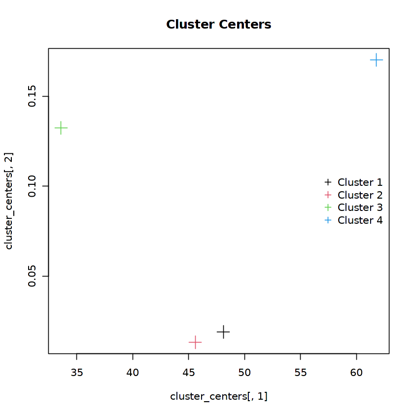

```r
# Define a function to visualize only cluster centers
visualize_cluster_centers <- function(cluster_centers, xlab, ylab) {
  # Create a scatter plot for cluster centers
  plot(cluster_centers[, 1], cluster_centers[, 2], col = 1:nrow(cluster_centers),
       pch = 3, cex = 2, xlab = xlab, ylab = ylab,
       main = "Cluster Centers")

  # Add legend for cluster centers
  legend("right", legend = paste("Cluster", 1:nrow(cluster_centers)),
         col = 1:nrow(cluster_centers), pch = 3, bty = "n")
}

# Extract variable names from kmeans1 object
xlab <- names(kmeans1$cluster_centers)[1]
ylab <- names(kmeans1$cluster_centers)[2]

# Visualize only cluster centers for df_KMeans1 with variable names from clustering result
visualize_cluster_centers(kmeans1$cluster_centers, xlab, ylab)
```

#### kmeans2 cluster center visualization

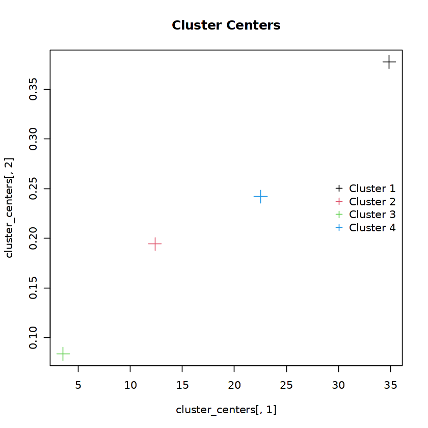

```r
# Define a function to visualize only cluster centers
visualize_cluster_centers <- function(cluster_centers, xlab, ylab) {
  # Create a scatter plot for cluster centers
  plot(cluster_centers[, 1], cluster_centers[, 2], col = 1:nrow(cluster_centers),
       pch = 3, cex = 2, xlab = xlab, ylab = ylab,
       main = "Cluster Centers")

  # Add legend for cluster centers
  legend("right", legend = paste("Cluster", 1:nrow(cluster_centers)),
         col = 1:nrow(cluster_centers), pch = 3, bty = "n")
}

# Extract variable names from kmeans1 object
xlab <- names(kmeans2$cluster_centers)[1]
ylab <- names(kmeans2$cluster_centers)[2]

# Visualize only cluster centers for df_KMeans2 with variable names from clustering result
visualize_cluster_centers(kmeans2$cluster_centers, xlab, ylab)
```

#### kmeans3 cluster center visualization

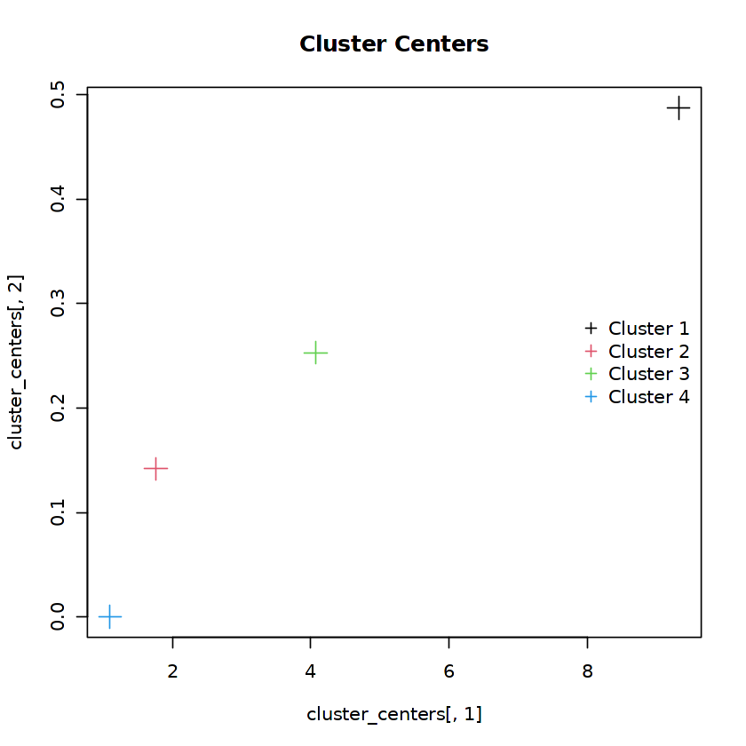

```r
# Define a function to visualize only cluster centers
visualize_cluster_centers <- function(cluster_centers, xlab, ylab) {
  # Create a scatter plot for cluster centers
  plot(cluster_centers[, 1], cluster_centers[, 2], col = 1:nrow(cluster_centers),
       pch = 3, cex = 2, xlab = xlab, ylab = ylab,
       main = "Cluster Centers")

  # Add legend for cluster centers
  legend("right", legend = paste("Cluster", 1:nrow(cluster_centers)),
         col = 1:nrow(cluster_centers), pch = 3, bty = "n")
}

# Extract variable names from kmeans1 object
xlab <- names(kmeans3$cluster_centers)[1]
ylab <- names(kmeans3$cluster_centers)[2]

# Visualize only cluster centers for df_KMeans3 with variable names from clustering result
visualize_cluster_centers(kmeans3$cluster_centers, xlab, ylab)
```

#### kmeans4 cluster center visualization

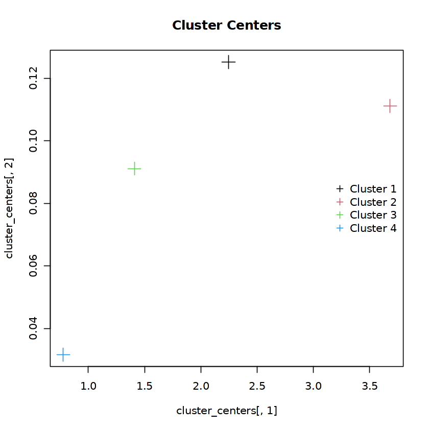

```r
# Define a function to visualize only cluster centers
visualize_cluster_centers <- function(cluster_centers, xlab, ylab) {
  # Create a scatter plot for cluster centers
  plot(cluster_centers[, 1], cluster_centers[, 2], col = 1:nrow(cluster_centers),
       pch = 3, cex = 2, xlab = xlab, ylab = ylab,
       main = "Cluster Centers")

  # Add legend for cluster centers
  legend("right", legend = paste("Cluster", 1:nrow(cluster_centers)),
         col = 1:nrow(cluster_centers), pch = 3, bty = "n")
}

# Extract variable names from kmeans1 object
xlab <- names(kmeans4$cluster_centers)[1]
ylab <- names(kmeans4$cluster_centers)[2]

# Visualize only cluster centers for df_KMeans4 with variable names from clustering result
visualize_cluster_centers(kmeans4$cluster_centers, xlab, ylab)
```

#### Summary

By plotting the cluster centers we can visually assess the separation between clusters  
and evaluate the effectiveness of the clustering algorithm in partitioning the data into distinct groups.

### Generate Cluster Profiles

**Note:** The `data` parameter in the cluster_profile() function represents the original dataset (i.e. df_KMeans1, df_KMeans2, ...) from which the cluster profiles are generated.

```r
# Define a function to generate cluster profiles
cluster_profile <- function(data, cluster_assignments) {
  # Combine data with cluster assignments
  data$cluster <- cluster_assignments

  # Compute summary statistics for each cluster
  cluster_summary <- aggregate(. ~ cluster, data, function(x) c(mean = mean(x), sd = sd(x)))

  # Return cluster profile
  return(cluster_summary)
}

# Generate cluster profiles for each dataframe
cluster_profile1 <- cluster_profile(df_KMeans1, kmeans1$cluster_assignments)
cluster_profile2 <- cluster_profile(df_KMeans2, kmeans2$cluster_assignments)
cluster_profile3 <- cluster_profile(df_KMeans3, kmeans3$cluster_assignments)
cluster_profile4 <- cluster_profile(df_KMeans4, kmeans4$cluster_assignments)

# Combine cluster profiles into a single list
all_cluster_profiles <- list(cluster_profile1, cluster_profile2, cluster_profile3, cluster_profile4)

# Print cluster profiles
for (i in 1:4) {
  cat("Cluster Profile for df_KMeans", i, ":\n")
  #print(summary(all_cluster_profiles[[i]]))
  cat("\n")
}
```

```
Cluster Profile for df_KMeans 1 :

Cluster Profile for df_KMeans 2 :

Cluster Profile for df_KMeans 3 :

Cluster Profile for df_KMeans 4 :
```

#### Summary

We generate cluster profiles which can be used in developing segmentation strategy either by identifying unique needs or different behaviors of customer segments.

### Visualize the Cluster Profiles

Using the mean and standard deviation vectors for each variables

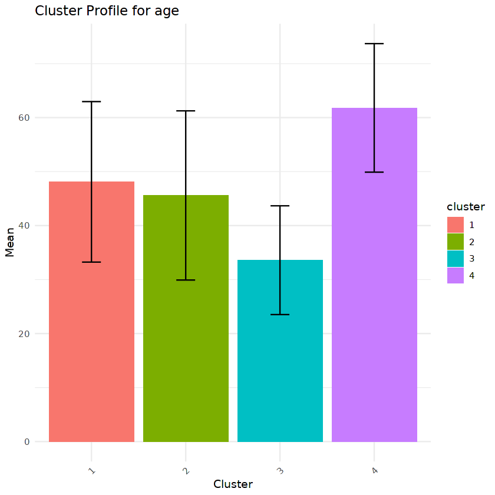

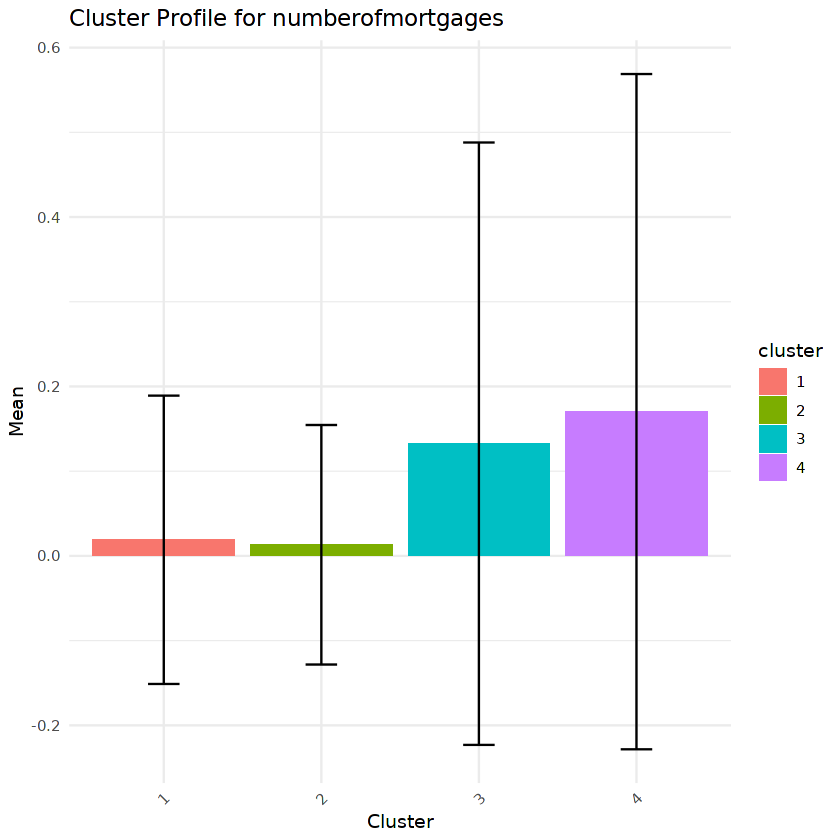

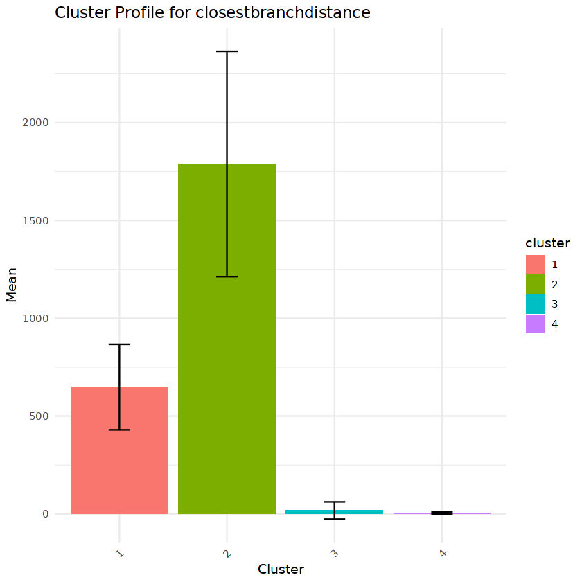

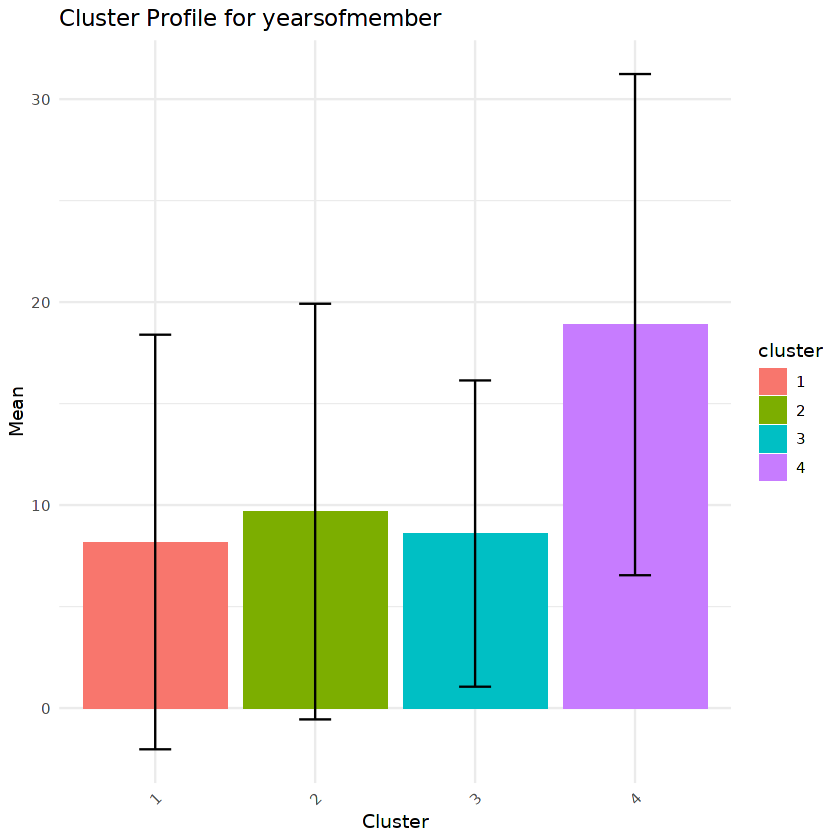

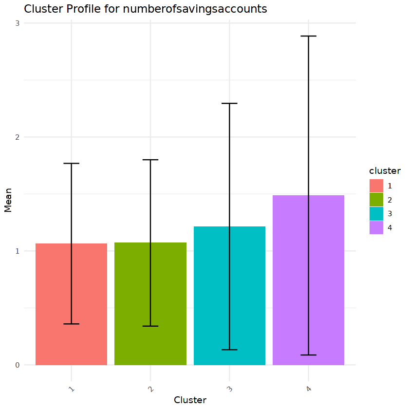

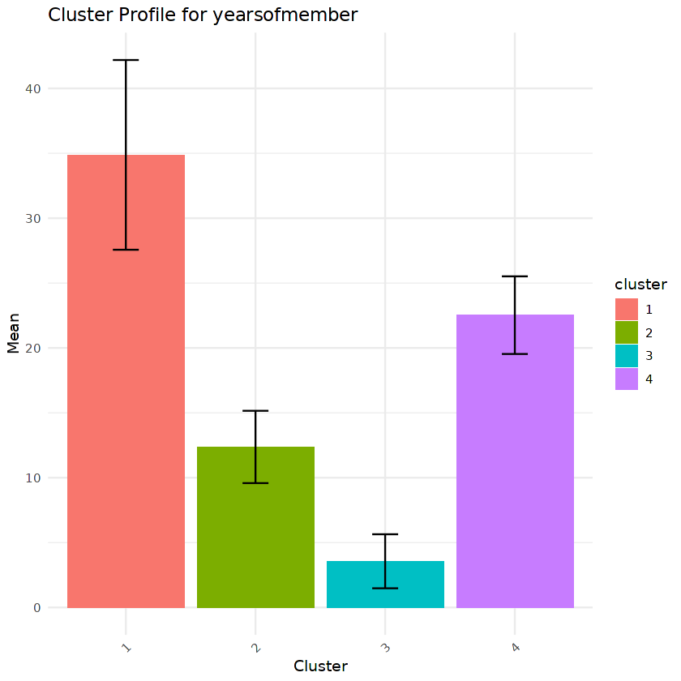

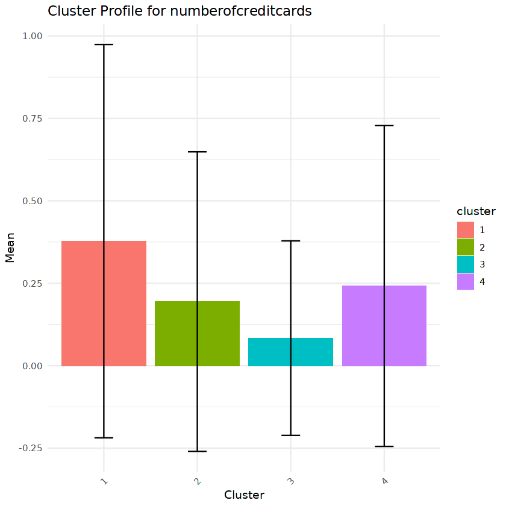

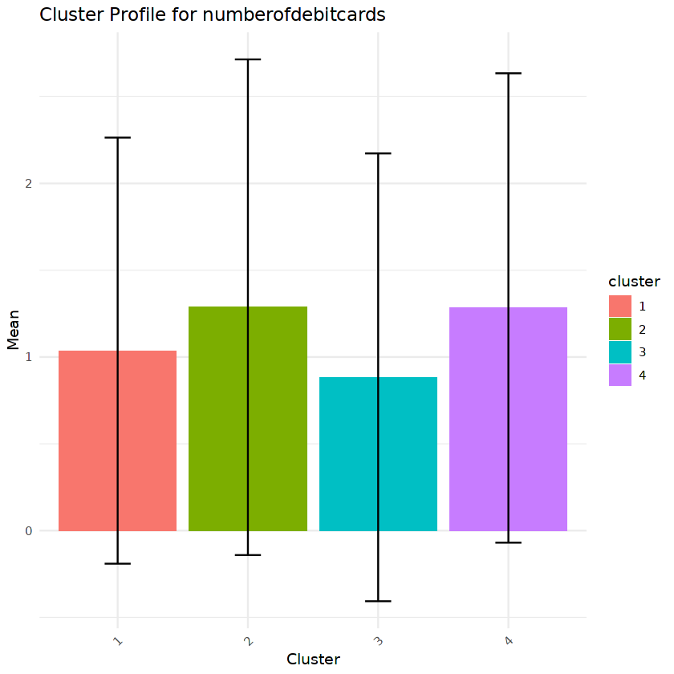

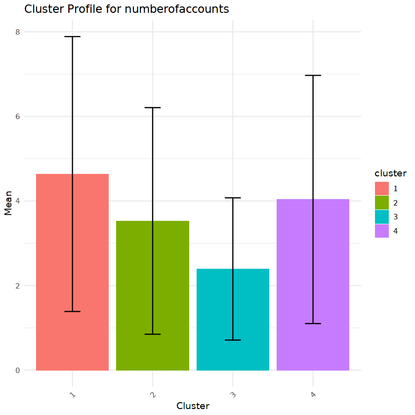

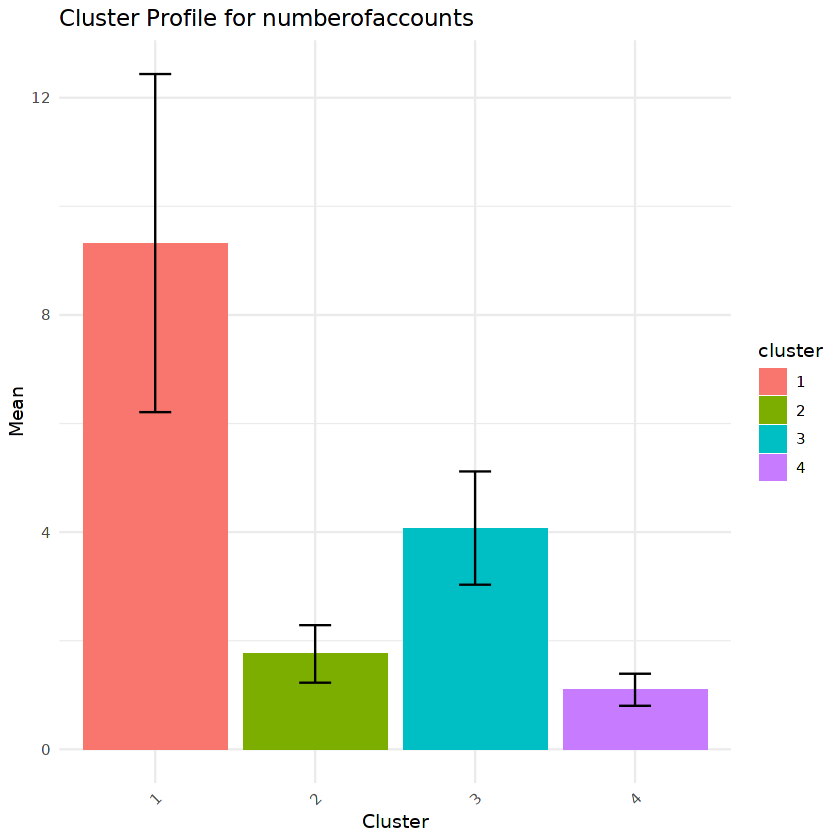

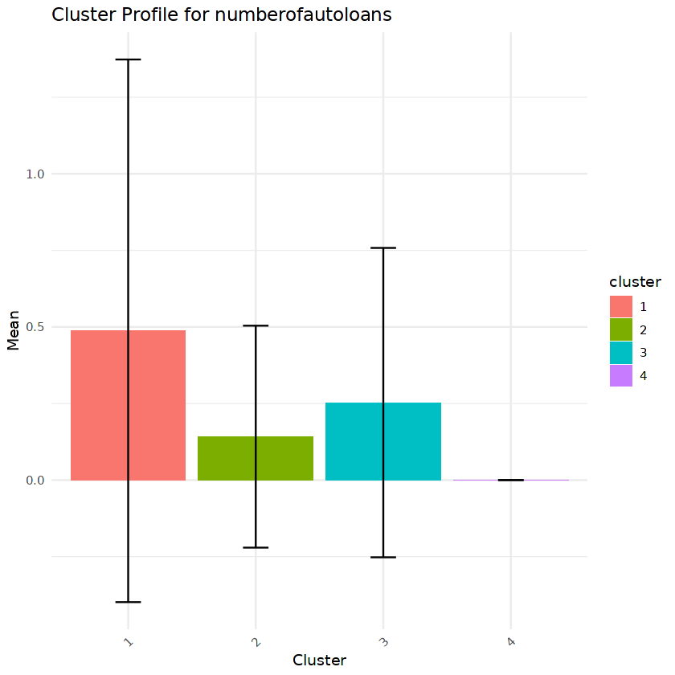

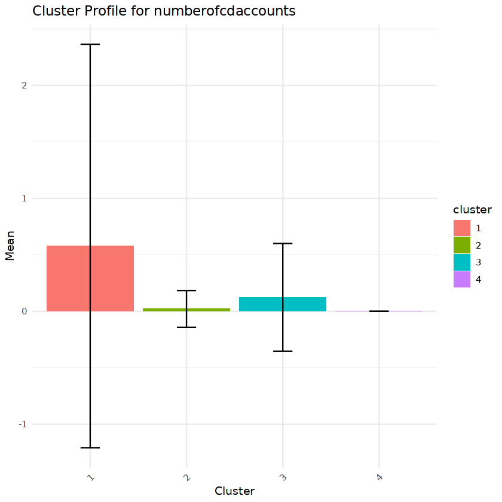

[5 more figures not shown]

```r
# Define a function to plot cluster profiles
plot_cluster_profiles <- function(cluster_profiles) {
  for (i in seq_along(cluster_profiles)) {
    cluster_profile <- cluster_profiles[[i]]

    # Create a bar plot for each cluster
    for (j in 2:ncol(cluster_profile)) { # Skip the first column (cluster)
      variable_name <- names(cluster_profile)[j]

      # Extract mean and standard deviation vectors for the variable
      means <- cluster_profile[[j]][, "mean"]
      sds <- cluster_profile[[j]][, "sd"]

      # Create a data frame for plotting
      bar_data <- data.frame(cluster = factor(cluster_profile$cluster),
                             mean = means,
                             sd = sds)

      # Plot the bar plot
      print(
        ggplot(bar_data, aes(x = cluster, y = mean, fill = cluster)) +
          geom_bar(stat = "identity") +
          geom_errorbar(aes(ymin = mean - sd, ymax = mean + sd), width = 0.2) +
          labs(title = paste("Cluster Profile for", variable_name),
               x = "Cluster", y = "Mean") +
          theme_minimal() +
          theme(axis.text.x = element_text(angle = 45, hjust = 1))
      )
    }
  }
}

# Call the function to plot cluster profiles
plot_cluster_profiles(all_cluster_profiles)
```

#### Summary

We skip the first column (cluster) because it contains the cluster labels, which we use to differentiate the bars in the plot.

We are interested in plotting the mean and standard deviation of each variable across different clusters, so we iterate over columns 2 to the last column of the cluster_profile data frame.

These columns represent the variables we are interested in analyzing.

### Pairwise Combination of Features Colored by Cluster Assignment

#### Explanation

We perform this analysis in order recognize patterns or associations between clusters that may not be evident when considering clusters individually.

The thought is that this analysis will provide a more comprehensive understanding of the data structure.

#### Pairwise feature combination for `kmeans1`

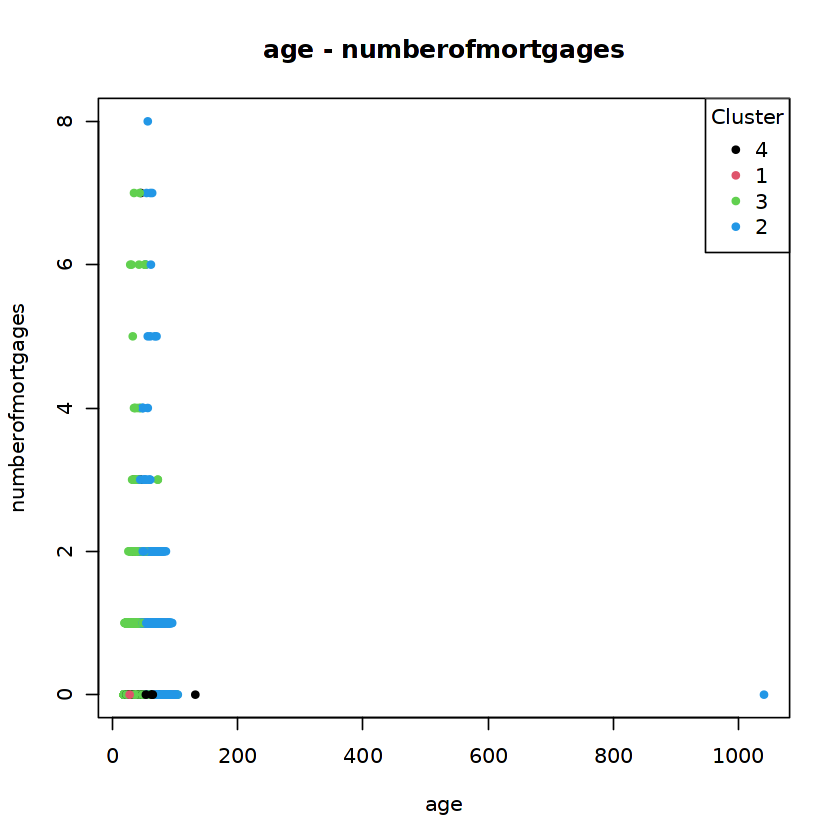

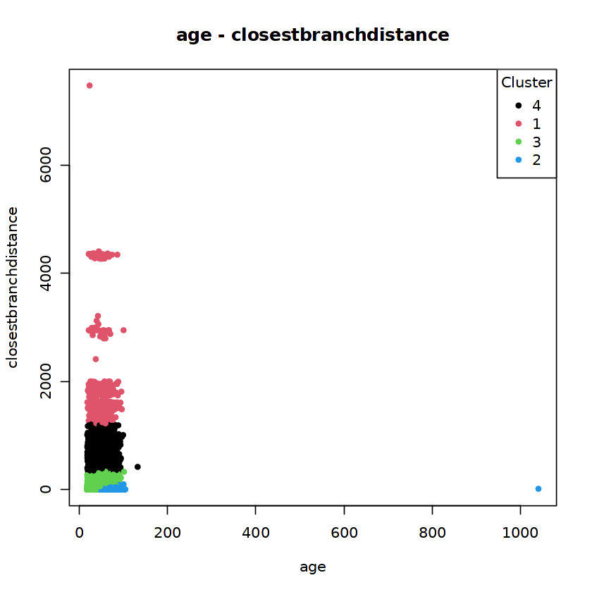

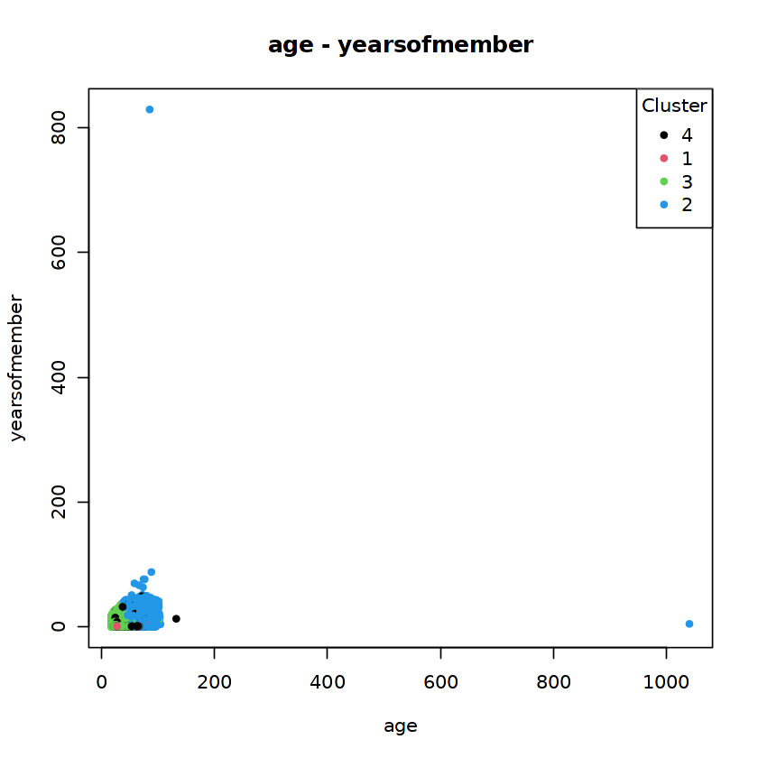

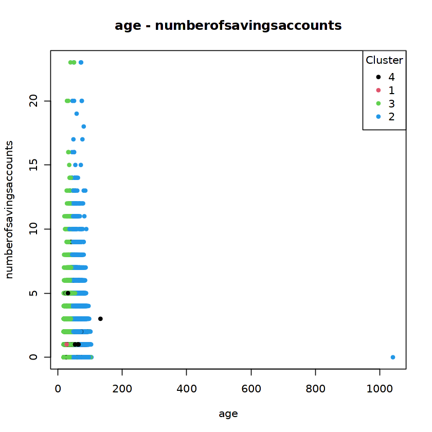

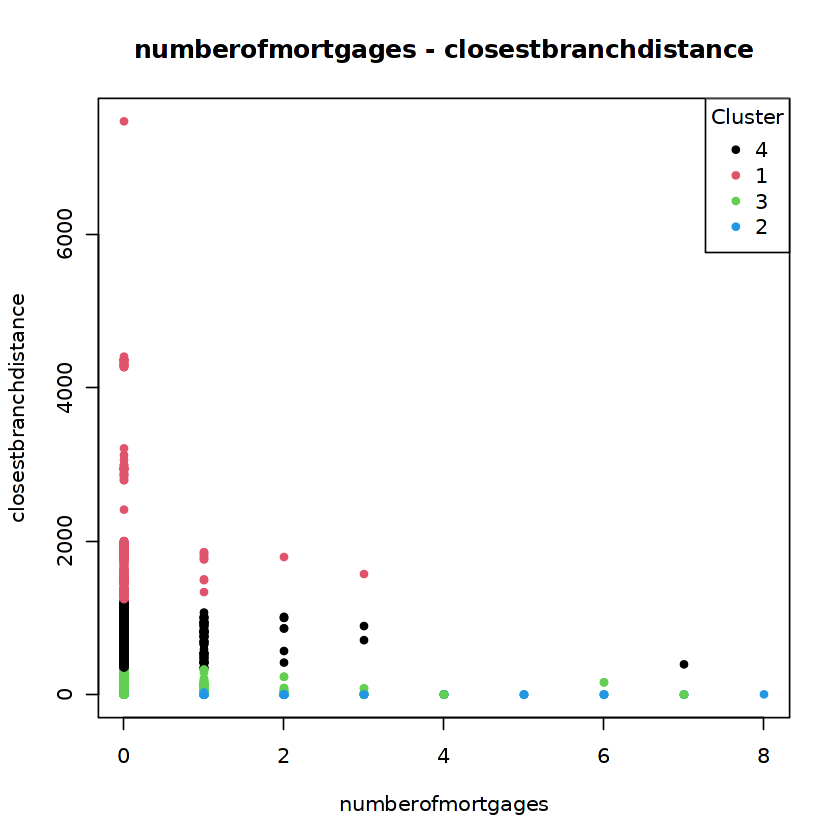

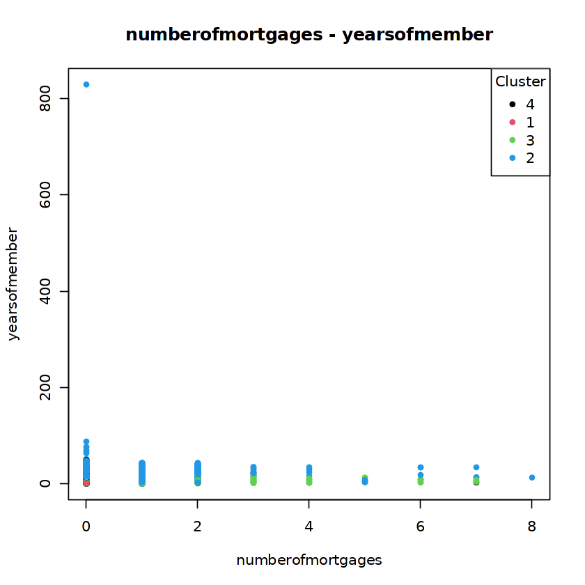

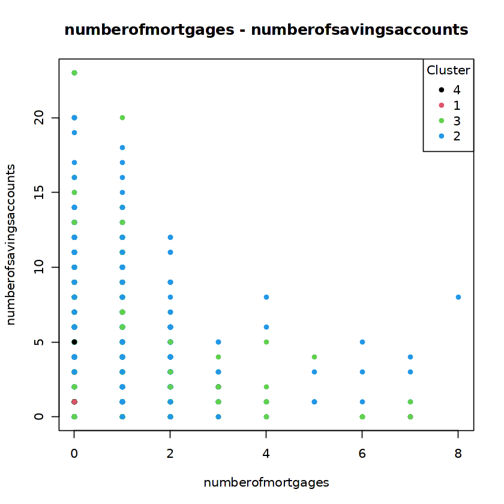

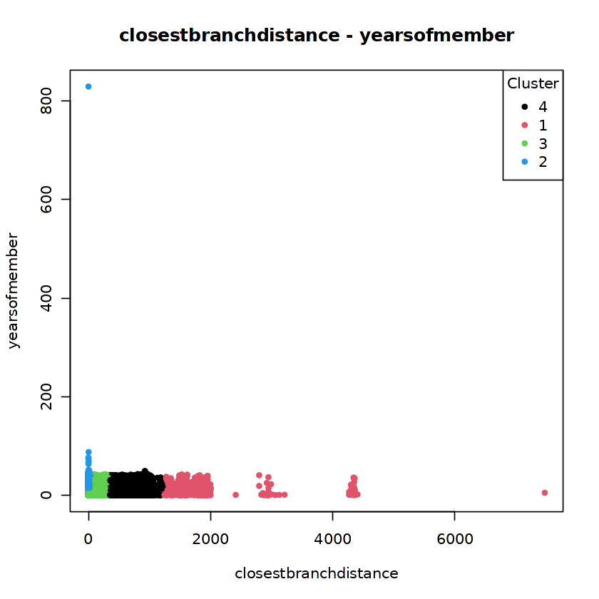

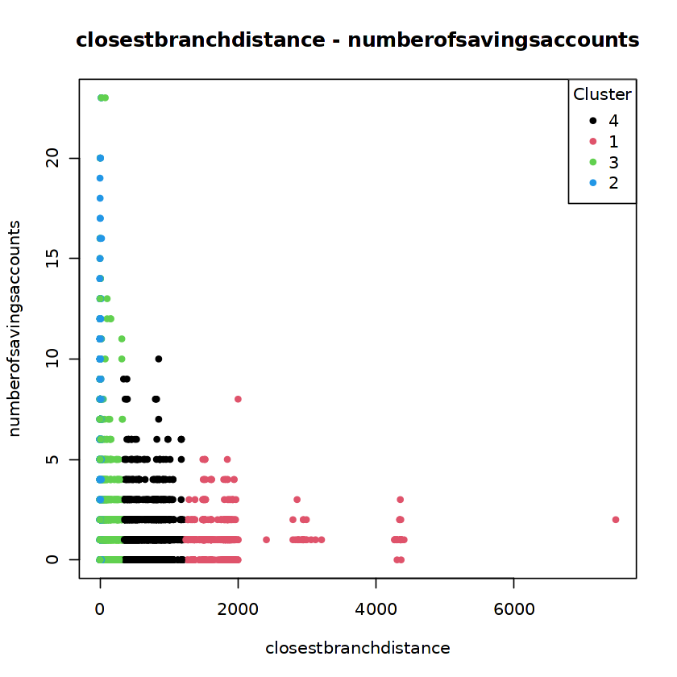

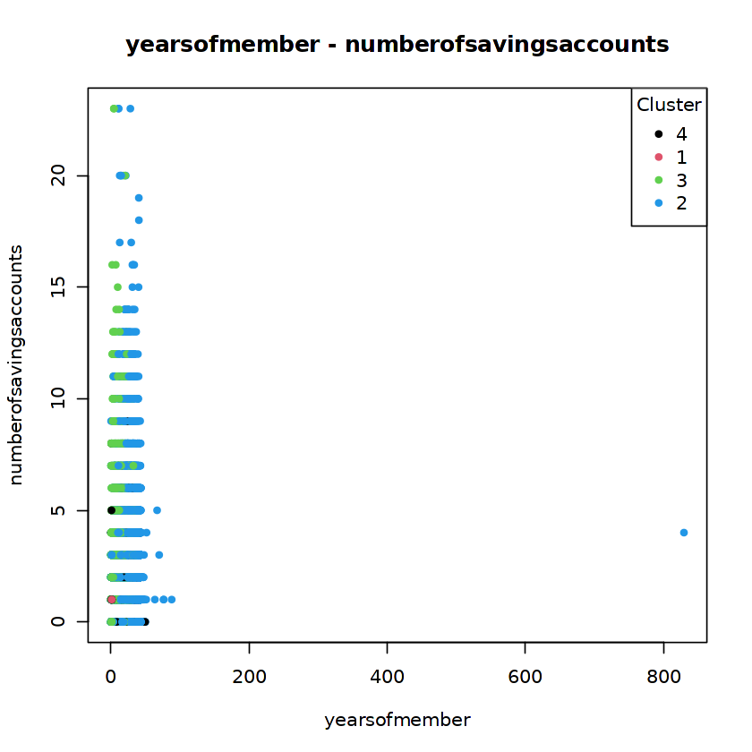

```r
# Define a function to plot pairwise combinations of features
plot_pairwise_clusters <- function(df, cluster_assignments, title) {
  # Get unique cluster assignments
  clusters <- unique(cluster_assignments)

  # Set up the plot layout
  par(mfrow=c(1,1))

  # Iterate over pairwise combinations of features
  for (i in 1:(ncol(df) - 1)) {
    for (j in (i + 1):ncol(df)) {
      # Plot each pairwise combination
      plot(df[, i], df[, j], col = cluster_assignments, pch = 20,
           xlab = names(df)[i], ylab = names(df)[j],
           main = paste(names(df)[i], "-", names(df)[j]))
      legend("topright", legend = clusters, col = 1:length(clusters), pch = 20, title = "Cluster")
    }
  }
}

# plot pairwise combinations of features colored by cluster assignment for kmeans1
plot_pairwise_clusters(df_KMeans1, kmeans1$cluster_assignments)
```